# **Analyzing Natural Disasters by Sentiment and Volume Generated on Reddit**

#### *HAYDEN OUTLAW | CMPS 6160 (Intro to Data Science) | Tulane University Fall '22*

Site: http://outlawhayden.github.io/

Git repository: https://github.com/outlawhayden/outlawhayden.github.io

## Proposal and Thesis

While climate change continues to transform global environments and ecologies, the evident destruction left by ever more frequent natural disasters is cause for alarm. As the damage grows with each storm, fire, or flood, public opinion has shifted significantly over the past two decades to favor environmental preservation and the mitigation of the effects of global warming.

However, while the increasing threat of natural disasters has sociological ripples, not all disasters have the same effect on public discourse. I hypothesize that traits about the disasters, including geographic location and traits about the countries impacted also affect the amount of discussion generated on Reddit about climate change. This is far from a definitive statement about all discourse across the entire internet, but attempts to begin to explore the relationship between attributes of disasters and how they create sociological change.

## Datasets

This project will focus on four different datasets from three separate sources:

The first is **“The Reddit Climate Change Dataset”**, compiled by user "lexyr" on Kaggle.com, available for download [*here*](https://www.kaggle.com/datasets/pavellexyr/the-reddit-climate-change-dataset)

This data will be used to measure social media discourse on climate change - while not representative of all discussion everywhere, it is a convenient and well-distributed sample of indivudially generated content, as opposed to that generated by companies or news outlets. In a future project, data from either more formal news sources, or different social media sites, could be taken to examine similarities and differences in discourse movement.

The second set is the **“EM-DAT Natural Disaster Dataset”**, compiled by the Center for Research on Epidemiology of Disasters, which can be queried [*here*](https://public.emdat.be/about)

This set compiles natural disasters as far back as 1900. It contains the location, time, date, type, magnitude, and various other attributes for natural disasters in all parts of the world. This database is definitely organized - it contains information from many different sources, both governmental and private, and as such inherits many extraneous attributes, and is thus composed of large patches of empty space. As such, it does require significant cleaning and processing before being viable for model use.

This data will be used to describe the effects of climate change, as it provides a detailed roster fo natural disasters, as well as their kind and location, which I hypothesize to be more correlated factors in generating content volume and sentiment changes on Reddit. This is one of the largest and most comprehensive databses of these kinds of events, and is an incredible free resource for tracking all kinds of natural-disaster related metrics. While many are parameters sparse, thhis project only requires the selection of a few metrics.

The third dataset is the **"Our World In Data: CO2 and Greenhouse Gas Emissions"** dataset, available for download [*here*](https://github.com/owid/co2-data)

This set compiles CO2 and other greenhouse gas emissions for each country from each year, starting at 1949 and up until 2020. It also contains unique demographics for each nation such as population and GDP, as well as a breakdown of the nation's share in global CO2 production from various sources. It is already very well preprocessed, and is continously maintained by the [Our World in Data](https://ourworldindata.org/) organization. This data will be used to express the relationship between nations' contribution to climate change, and the effect that they have on climate change discourse when they are affected by natural disasters.

The fourth dataset is the **Our World in Data: Internet Penetration"** dataset, available for downlaod [*here*](https://ourworldindata.org/internet)

This set is also mantained by the [Our World in Data](https://ourworldindata.org/) organization, but measures the penetration of internet access for each nation, across time. The official unit of measurement is the total number of unique users that have accessed the internet at any given point in the last three months across any point in the nation.

This is used to attempt to counteract the obvious bias that this analysis has towards nations and demographics that have better internet access and more engaged users. While data for the number of specifically Reddit users by nation and time was difficult to find, this metric can serve as a proxy for that to at least partially compensate for this bias.

# Important Questions

- Can content creation and sentiment be predicted using natural disaster data?
- What features are the most important in these models and have the most influence?
- How do models perform when trained on disparate partitions of the data?
- What biases in climate change discourse do these models uncover?

# Project Plan

After cleaning and manipulating the datasets, and generating new sentiment scores, the plan is to categorize all Reddit content data by date, and then examine the impact that each natural disaster had on both the volume and sentiment of online discourse both on that day and in the near future. If possible, the next step is to regress this information backwards: given some natural disaster, is it possible to predict the change in online content ahead of time? From this, various questions could be answered about climate change sentiment. For instance, which nations are most generate the most content, or most dramatic swing in sentiment when affected by climate change? What portions of the world generate more discourse when impacted by natural disasters, in either a positive or negative direction?

After this exploratory analysis, a regressive model will be created to see if the future climate change discourse on a given day can be predicted using traits of natural disasters happening on that day. The data that this model will be trained on will be a join of both the natural disaster data and the Reddit scraping data, aggregated by mean over specific dates. Once this is done, different iterations will be created trained on separate partitioning of the data, and the models can be analyzed to uncover the singificance of each parameter to examine the relationships underpinning content generation and natural disasters.

## Importing Libraries

```python
import numpy as np
import sys
import sklearn
import os
import matplotlib as mpl
import matplotlib.pyplot as plt
from urllib.request import urlretrieve
import zipfile
import pandas as pd
import seaborn as sns
sns.set_style("whitegrid")
import datetime as dt
import matplotlib.dates as mdates
import geopandas as gpd
from sklearn.model_selection import train_test_split
from sklearn.preprocessing import StandardScaler
from sklearn.neighbors import KNeighborsRegressor
import xgboost as xgb
from sklearn.impute import KNNImputer
from sklearn.impute import SimpleImputer
from sklearn.pipeline import Pipeline
from sklearn.metrics import mean_squared_error
from scipy.spatial.distance import squareform
```

## Reading Data

The EM-DAT Dataset:

- Queried Sep 28 2022
- n = 25632

The "Reddit Climate Change" Dataset:

- Copied Sep 28 2022
- Comment Data: n = 4600698
- Post Data: n = 620908

The "OWID CO2" Dataset:

- Downloaded Nov 2 2022
- Regions/Nations: n = 26008

The "OWID Internet" Dataset:

- Downloaded Dec 6 2022
- Regions/Nations: n = 6379

This reads all data from `.csv` files into Pandas dataFrame objects. Since the EM-DAT and CO2 Emission datasets contain so many attributes, the `low_memory` flag is set to false for processing time, speeding up the type inference for each attribute

```python
# Read .csv data into Pandas dataframe objects
disaster_data = pd.read_csv("data_/disaster_data.csv", low_memory = False)
reddit_comment_data = pd.read_csv("data_/redditdata/comment_data.csv")
reddit_post_data = pd.read_csv("data_/redditdata/post_data.csv")
co2_data = pd.read_csv("data_/co2_data.csv", low_memory = False)
internet_data = pd.read_csv("data_/number-of-internet-users.csv", low_memory = False)
```

## Data Cleaning

For the Natural Disaster dataset, there were a lot of columns that were mostly empty, or meaningless, as the set was aggregated from a wide variety of sources, and a lot of artifact attributes carried over. All of the empty or irreferential columns were dropped from the set, preserving generally only the more broad metrics that are mostly complete.

For the OWID CO2 dataset, there are many various CO2 statistics included in the table, but the majority of them are sparse, or not useful to this project due to hyper-specificity. As well, there are metrics for certain regions, or continents, that are aggregates of various smaller sub-regions, the unit of measurement is not consistently one nation for one year. For these purposes, this project will only examine nation-by-nation metrics, and drop all regional aggregates.

The OWID Internet dataset is already very clean and well formatted with no holes or missing data. The only thing to do is to strip away the full nation name as it's redundant with the ISO code that will be used to join it with other tables.

Finally, to guarantee that the disparate databases can interact with each other with regards to time, the various date information is converted into python `datetime` objects, which can be filtered, sorted, and joined on. Note that since the data will only be considered on a yearly basis, various datetime details such as time zone, leap years, etc., can be safely ignored.

```python
# Drop empty/artifact columns, create new frame so data does not have to be reloaded
disaster_data = disaster_data.drop(["Glide", "Disaster Subsubtype", "Origin", "Associated Dis", "Associated Dis2", "OFDA Response", "Appeal", "Declaration", "AID Contribution ('000 US$)", "Dis Mag Value", "Dis Mag Scale", "River Basin", "No Injured", "No Affected", "No Homeless", "Total Affected","Reconstruction Costs ('000 US$)", "Reconstruction Costs, Adjusted ('000 US$)", "Insured Damages ('000 US$)", "Insured Damages, Adjusted ('000 US$)", "Total Damages ('000 US$)", "Total Damages, Adjusted ('000 US$)", "Adm Level", "Admin1 Code", "Admin2 Code", "Geo Locations"], axis = 1)

# Drop all data before 2010
disaster_data = disaster_data.loc[disaster_data["Start Year"] >= 2010]

# Create datetime object columns for start and end date, drop redundant date columns
disaster_data["Start Date"] = pd.to_datetime(dict(year = disaster_data["Start Year"], month = disaster_data["Start Month"], day = disaster_data["Start Day"]), errors = 'coerce')
disaster_data["End Date"] = pd.to_datetime(dict(year = disaster_data["End Year"], month = disaster_data["End Month"], day = disaster_data["End Day"]), errors = 'coerce')
disaster_data.drop(["Start Year", "Start Month", "Start Day", "End Year", "End Month", "End Day"], inplace = True, axis = 1)
disaster_data.head()
```

|  | Dis No | Year | Seq | Disaster Group | Disaster Subgroup | Disaster Type | Disaster Subtype | Event Name | Country | ISO | Region | Continent | Location | Latitude | Longitude | Local Time | Total Deaths | CPI | Start Date | End Date |
| --- | --- | --- | --- | --- | --- | --- | --- | --- | --- | --- | --- | --- | --- | --- | --- | --- | --- | --- | --- | --- |
| 18018 | 2009-0595-IND | 2009 | 595 | Natural | Meteorological | Extreme temperature | Cold wave | NaN | India | IND | Southern Asia | Asia | Srinagar city ('72808' district, '40424' Jammu... | NaN | NaN | NaN | 100.0 | 79.173803 | 2010-01-02 | 2010-01-13 |
| 18033 | 2010-0179-CHN | 2010 | 179 | Natural | Meteorological | Storm | Convective storm | NaN | China | CHN | Eastern Asia | Asia | Chongqing Shi province | NaN | NaN | NaN | 29.0 | 80.472285 | 2010-05-06 | 2010-05-06 |
| 18034 | 2010-0484-CHN | 2010 | 484 | Natural | Meteorological | Storm | Tropical cyclone | Typhoon Fanapi | China | CHN | Eastern Asia | Asia | Fujian Sheng, Guangdong Sheng provinces | NaN | NaN | NaN | 75.0 | 80.472285 | 2010-09-20 | 2010-09-20 |
| 18035 | 2010-0503-GTM | 2010 | 503 | Natural | Meteorological | Storm | Tropical cyclone | Tropical storm Matthew | Guatemala | GTM | Central America | Americas | Peten, Isabel, Suchitepequez, Huehuetenango, E... | NaN | NaN | NaN | NaN | 80.472285 | 2010-09-25 | 2010-09-25 |
| 18036 | 2010-0692-ITA | 2010 | 692 | Natural | Meteorological | Storm | Convective storm | NaN | Italy | ITA | Southern Europe | Europe | Veneto, Toscana, Liguria, Valle D'aosta, Lomba... | NaN | NaN | NaN | 3.0 | 80.472285 | 2010-10-31 | 2010-11-02 |

```python
# Create human-readable date column, strip columns of whitespace

reddit_post_data["date"] = pd.to_datetime(reddit_post_data["created_utc"], unit = "s").dt.date
reddit_post_data.columns = reddit_post_data.columns.str.strip()
reddit_post_data.head()
```

|  | type | id | subreddit.id | subreddit.name | subreddit.nsfw | created_utc | permalink | domain | url | selftext | title | score | date |
| --- | --- | --- | --- | --- | --- | --- | --- | --- | --- | --- | --- | --- | --- |
| 0 | post | x2smmw | 2vh0v | democraticsocialism | False | 1661990237 | https://old.reddit.com/r/DemocraticSocialism/c... | twitter.com | https://twitter.com/SusanofTexas/status/156480... | NaN | “Cities without water” is our future. The lead... | 15 | 2022-08-31 |
| 1 | post | x2slxy | 2w844 | nostupidquestions | False | 1661990182 | https://old.reddit.com/r/NoStupidQuestions/com... | self.nostupidquestions | NaN | Ok so I was having a conversation with my neig... | Sharks and climate change | 2 | 2022-08-31 |
| 2 | post | x2slk5 | 6wzx9b | eduwriters | False | 1661990150 | https://old.reddit.com/r/EduWriters/comments/x... | eduwriters.pro | https://eduwriters.pro/?cid=2860/?utm_source=r... | NaN | How to start a climate change essay | 1 | 2022-08-31 |
| 3 | post | x2sbz6 | 46adh7 | alternatitvereality | False | 1661989389 | https://old.reddit.com/r/AlternatitveReality/c... | i.imgur.com | https://i.imgur.com/wJbchkQ.jpg | NaN | Ever notice that when it’s hot a few days in J... | 1 | 2022-08-31 |
| 4 | post | x2sa2a | 2qh1i | askreddit | False | 1661989240 | https://old.reddit.com/r/AskReddit/comments/x2... | self.askreddit | NaN | [deleted] | How would you react if the next American presi... | 1 | 2022-08-31 |

```python
# Create human-readable date columns, strip columns of whitespace
reddit_comment_data["date"] = pd.to_datetime(reddit_comment_data["created_utc"], unit = "s").dt.date
reddit_comment_data.columns = reddit_comment_data.columns.str.strip()

# Drop preexisting sentiment analysis
reddit_comment_data.drop(["sentiment"], inplace = True, axis = 1)
reddit_comment_data.head()
```

|  | type | id | subreddit.id | subreddit.name | subreddit.nsfw | created_utc | permalink | body | score | date |
| --- | --- | --- | --- | --- | --- | --- | --- | --- | --- | --- |
| 0 | comment | imlddn9 | 2qh3l | news | False | 1661990368 | https://old.reddit.com/r/news/comments/x2cszk/... | Yeah but what the above commenter is saying is... | 2 | 2022-08-31 |
| 1 | comment | imldbeh | 2qn7b | ohio | False | 1661990340 | https://old.reddit.com/r/Ohio/comments/x2awnp/... | Any comparison of efficiency between solar and... | 2 | 2022-08-31 |
| 2 | comment | imldado | 2qhma | newzealand | False | 1661990327 | https://old.reddit.com/r/newzealand/comments/x... | I'm honestly waiting for climate change and th... | 1 | 2022-08-31 |
| 3 | comment | imld6cb | 2qi09 | sacramento | False | 1661990278 | https://old.reddit.com/r/Sacramento/comments/x... | Not just Sacramento. It's actually happening a... | 4 | 2022-08-31 |
| 4 | comment | imld0kj | 2qh1i | askreddit | False | 1661990206 | https://old.reddit.com/r/AskReddit/comments/x2... | I think climate change tends to get some peopl... | 1 | 2022-08-31 |

```python
# Drop country name
internet_data.drop(["Entity"], inplace = True, axis = 1)

# Drop data not tied to a certain country
internet_data.dropna(axis = 0, subset = ["Code"], inplace = True)

# Filter by date
internet_data = internet_data.loc[internet_data["Year"]>= 2010]

# Convert date to datetime objects
internet_data["Year"] = pd.to_datetime(internet_data["Year"], format = "%Y").dt.year
internet_data
```

|  | Code | Year | Number of Internet users |
| --- | --- | --- | --- |
| 15 | AFG | 2010 | 1127587 |
| 16 | AFG | 2011 | 1462458 |
| 17 | AFG | 2012 | 1661808 |
| 18 | AFG | 2013 | 1860932 |
| 19 | AFG | 2014 | 2290135 |
| ... | ... | ... | ... |
| 6374 | ZWE | 2016 | 3341464 |
| 6375 | ZWE | 2017 | 3599269 |
| 6376 | ZWE | 2018 | 3763048 |
| 6377 | ZWE | 2019 | 3854006 |
| 6378 | ZWE | 2020 | 4591211 |

2088 rows × 3 columns

```python
# Drop data not tied to a certain country
co2_data.dropna(axis = 0, subset = ["iso_code"], inplace = True)

# Drop sparse attributes
co2_data.drop(["cement_co2","cement_co2_per_capita","co2_per_gdp","co2_per_unit_energy","consumption_co2", "consumption_co2_per_capita", "consumption_co2_per_gdp","cumulative_cement_co2","cumulative_flaring_co2","cumulative_gas_co2", "cumulative_oil_co2","cumulative_other_co2","energy_per_capita","energy_per_gdp","flaring_co2", "flaring_co2_per_capita", "gas_co2","gas_co2_per_capita","ghg_excluding_lucf_per_capita","ghg_per_capita","methane", "methane_per_capita", "nitrous_oxide", "nitrous_oxide_per_capita", "oil_co2", "oil_co2_per_capita", "other_co2_per_capita", "other_industry_co2", "primary_energy_consumption", "share_global_cement_co2", "share_global_coal_co2","share_global_cumulative_cement_co2","share_global_cumulative_coal_co2","share_global_cumulative_flaring_co2","share_global_cumulative_gas_co2", "share_global_cumulative_oil_co2", "share_global_cumulative_other_co2","share_global_flaring_co2", "share_global_gas_co2", "share_global_oil_co2", "share_global_other_co2", "total_ghg", "total_ghg_excluding_lucf", "trade_co2", "trade_co2_share"],axis = 1, inplace = True)

# Convert year column to datetime objects
co2_data["Year"] = pd.to_datetime(co2_data["year"], format = "%Y").dt.year
co2_data.head()
```

|  | country | year | iso_code | population | gdp | co2 | co2_growth_abs | co2_growth_prct | co2_per_capita | coal_co2 | coal_co2_per_capita | cumulative_co2 | cumulative_coal_co2 | share_global_co2 | share_global_cumulative_co2 | Year |
| --- | --- | --- | --- | --- | --- | --- | --- | --- | --- | --- | --- | --- | --- | --- | --- | --- |
| 0 | Afghanistan | 1949 | AFG | 7624058.0 | NaN | 0.015 | NaN | NaN | 0.002 | 0.015 | 0.002 | 0.015 | 0.015 | 0.0 | 0.0 | 1949 |
| 1 | Afghanistan | 1950 | AFG | 7752117.0 | 9.421400e+09 | 0.084 | 0.070 | 475.0 | 0.011 | 0.021 | 0.003 | 0.099 | 0.036 | 0.0 | 0.0 | 1950 |
| 2 | Afghanistan | 1951 | AFG | 7840151.0 | 9.692280e+09 | 0.092 | 0.007 | 8.7 | 0.012 | 0.026 | 0.003 | 0.191 | 0.061 | 0.0 | 0.0 | 1951 |
| 3 | Afghanistan | 1952 | AFG | 7935996.0 | 1.001733e+10 | 0.092 | 0.000 | 0.0 | 0.012 | 0.032 | 0.004 | 0.282 | 0.093 | 0.0 | 0.0 | 1952 |
| 4 | Afghanistan | 1953 | AFG | 8039684.0 | 1.063052e+10 | 0.106 | 0.015 | 16.0 | 0.013 | 0.038 | 0.005 | 0.388 | 0.131 | 0.0 | 0.0 | 1953 |

## Sentiment Analysis

While the Reddit dataset contained citations for how the information was extracted from Reddit's API, the pre-packaged sentiment analysis was uncited. For consistency, sentiment analysis on the text body in each of the samples from Reddit is done here using the **VADER (Valence Aware Dictionary and sEntiment Reasoner) Model**, which is a rule-based sentiment analysis tool designed specifically for social media content. It was originally trained on large quantities of internet-based text from websites such as Twitter, Rotten Tomatoes, and Amazon, and is chosen for this project because of the similarity in text style between its original training data and the text scraped from Reddit.

*The model is public and open source, and the source code is available here: https://github.com/cjhutto/vaderSentiment*

***Note that this step is computationally intensive, and depending on the underlying kernel and hardware, could take a few (>12) hours to process***

```python
# Import VADER sentiment module
from vaderSentiment.vaderSentiment import SentimentIntensityAnalyzer

# Create sentiment analysis object
sid_obj = SentimentIntensityAnalyzer()

def get_vader_sentiment(str):
    return sid_obj.polarity_scores(str)["compound"]

# Create new column of sentiment score for all content bodies
reddit_post_data["sentiment"] = reddit_post_data["title"].apply(get_vader_sentiment)
reddit_comment_data["sentiment"] = reddit_comment_data["body"].apply(get_vader_sentiment)
reddit_post_data.head()
```

|  | type | id | subreddit.id | subreddit.name | subreddit.nsfw | created_utc | permalink | domain | url | selftext | title | score | date | sentiment |
| --- | --- | --- | --- | --- | --- | --- | --- | --- | --- | --- | --- | --- | --- | --- |
| 0 | post | x2smmw | 2vh0v | democraticsocialism | False | 1661990237 | https://old.reddit.com/r/DemocraticSocialism/c... | twitter.com | https://twitter.com/SusanofTexas/status/156480... | NaN | “Cities without water” is our future. The lead... | 15 | 2022-08-31 | -0.6908 |
| 1 | post | x2slxy | 2w844 | nostupidquestions | False | 1661990182 | https://old.reddit.com/r/NoStupidQuestions/com... | self.nostupidquestions | NaN | Ok so I was having a conversation with my neig... | Sharks and climate change | 2 | 2022-08-31 | 0.0000 |
| 2 | post | x2slk5 | 6wzx9b | eduwriters | False | 1661990150 | https://old.reddit.com/r/EduWriters/comments/x... | eduwriters.pro | https://eduwriters.pro/?cid=2860/?utm_source=r... | NaN | How to start a climate change essay | 1 | 2022-08-31 | 0.0000 |
| 3 | post | x2sbz6 | 46adh7 | alternatitvereality | False | 1661989389 | https://old.reddit.com/r/AlternatitveReality/c... | i.imgur.com | https://i.imgur.com/wJbchkQ.jpg | NaN | Ever notice that when it’s hot a few days in J... | 1 | 2022-08-31 | 0.1655 |
| 4 | post | x2sa2a | 2qh1i | askreddit | False | 1661989240 | https://old.reddit.com/r/AskReddit/comments/x2... | self.askreddit | NaN | [deleted] | How would you react if the next American presi... | 1 | 2022-08-31 | -0.1531 |

```python
# Save preprocessed data to memory

if not os.path.isfile("data_/disaster_data_processed.csv"):
    disaster_data.to_csv("data_/disaster_data_processed.csv")

if not os.path.isfile("data_/co2_data_processed.csv"):
    co2_data.to_csv("data_/co2_data_processed.csv")

if not os.path.isfile("data_/redditdata/comment_data_processed.csv"):
    reddit_comment_data.to_csv("data_/redditdata/comment_data_processed.csv")

if not os.path.isfile("data_/redditdata/post_data_processed.csv"):
    reddit_post_data.to_csv("data_/redditdata/post_data_processed.csv")

if not os.path.isfile("data_/number-of-internet-users_processed.csv"):
    internet_data.to_csv("data_/number-of-internet-users_processed.csv")
```

```python
# Load processed data from saved files
disaster_data = pd.read_csv("data_/disaster_data_processed.csv", low_memory = False,lineterminator='\n')
reddit_comment_data = pd.read_csv("data_/redditdata/comment_data_processed.csv", low_memory = False,lineterminator='\n')
reddit_post_data = pd.read_csv("data_/redditdata/post_data_processed.csv", low_memory = False,lineterminator='\n')
co2_data = pd.read_csv("data_/co2_data_processed.csv", low_memory = False,lineterminator='\n')
internet_data = pd.read_csv("data_/number-of-internet-users_processed.csv", low_memory = False, lineterminator = "\n")
```

## Exploratory Data Analysis

Exploring this data will take some shaping, as there are two fundamental units of observation here: countries and dates.

First, the trends in the Reddit data will be examined with respect to volume and sentiment across time with a visualization to see if there are certain dates around which there is more activity than average. Next, the social media data on each day will be joined with natural disaster data to examine the relationship between the two. After that, the aggregate volume and sentiment on certain days of natural disasters will be aggregated by nation, to see if there is a relationship between the disasters and their discourse generation and traits of the affected nations, specifically CO2 emission and national GDP.

### Time Series Exploratory Analysis

To analyze the Reddit data across time, two new frames are created, grouping the overall score and sentiment value by day as a mean. Next, the count of comments or posts are agreggated, and added to the data sorted by day. This makes it easier to look at the relationship between individual or multiple days and broader movements in sentiment, and to begin investigating the relationship they might have.

```python
# Group by date for quantitative data, and rename columns
reddit_comment_days = reddit_comment_data[["sentiment","score"]].groupby(reddit_comment_data["date"]).mean()
reddit_comment_days.columns = ["average sentiment", "average score"]
```

```python
# Group by date for quantitative data, and rename columns
reddit_post_days = reddit_post_data[["sentiment", "score"]].groupby(reddit_post_data["date"]).mean()
reddit_post_days.columns = ["average sentiment", "average score"]
```

```python
# create aggregates for comment volume and post volume for each day
reddit_comment_days["comment volume"] = reddit_comment_data["date"].value_counts()
reddit_post_days["post volume"] = reddit_post_data["date"].value_counts()

# reset indices, reformat datetime objects
reddit_comment_days.reset_index(inplace = True)
reddit_comment_days["date"] = pd.to_datetime(reddit_comment_days["date"]).dt.date
reddit_post_days.reset_index(inplace = True)
reddit_post_days["date"] = pd.to_datetime(reddit_comment_days["date"]).dt.date
```

```python
reddit_comment_days.head()
```

|  | date | average sentiment | average score | comment volume |
| --- | --- | --- | --- | --- |
| 0 | 2010-01-01 | 0.090138 | 3.384615 | 13 |
| 1 | 2010-01-02 | -0.004041 | 3.081081 | 37 |
| 2 | 2010-01-03 | -0.089100 | 2.125000 | 32 |
| 3 | 2010-01-04 | 0.002576 | 3.489796 | 49 |
| 4 | 2010-01-05 | 0.095035 | 1.467742 | 62 |

```python
reddit_post_days.head()
```

|  | date | average sentiment | average score | post volume |
| --- | --- | --- | --- | --- |
| 0 | 2010-01-01 | -0.112400 | 1.818182 | 11 |
| 1 | 2010-01-02 | 0.025733 | 1.333333 | 6 |
| 2 | 2010-01-03 | -0.085824 | 3.235294 | 17 |
| 3 | 2010-01-04 | -0.001973 | 2.045455 | 22 |
| 4 | 2010-01-05 | -0.151536 | 2.055556 | 36 |

### Comment and Post Volume and Sentiment Across Time

This plot examines both comment volume and sentiment across time, as well as post volume across time. Notably, after 2016, both the volume of comments and posts containing 'climate change' began to rise heavily, but the average sentiment of the material began to tend to be more negative. Furthermore, as time progresses, the content volume becomes more disperesed, with individual days or periods showing greater spikes in activity, which could hint at being generated by certain events or ocurrences on specific days. This could also show the use of Reddit changing over time, becoming more an outlet for climate change discourse as time and the frequency of disasters increases.

Although initially the comment and post media seem similar, the mechanism for their generation and their distinct statistical behavior is the motivation for keeping them separate in the future instead of just appending them or taking an aggregate. Comments are generated as shorter strings of text, are less visible, but more often used for engagement and discourse within Reddit, whereas posts are longer formatted and geared more for larger visibility, but used less for interpersonal conversation and discourse. Their quanitiative depictions also appear different, and to preserve the underlying information they should remain distinct.

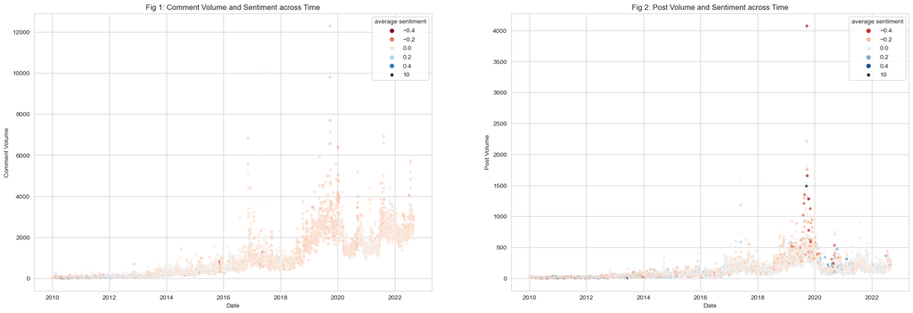

```python
# Plot comment volume across time (assign hue to sentiment)

fig,axes = plt.subplots(1,2, figsize = (25, 8))


cd_plt = sns.scatterplot(ax = axes[0],data = reddit_comment_days, x = "date", y = "comment volume", hue = "average sentiment", palette = "RdBu",alpha = 0.7, size = 10, edgecolor = None)
cd_plt.set(title = "Fig 1: Comment Volume and Sentiment across Time")
axes[0].set_xlabel("Date")
axes[0].set_ylabel("Comment Volume")

# Plot post volume across time (no sentiment analysis on post content, so fixed hue)
pd_plt = sns.scatterplot(ax = axes[1],data = reddit_post_days, x = "date", y = "post volume", hue = "average sentiment", palette = "RdBu",alpha = 0.7, size = 10, edgecolor = None)
pd_plt.set(title = "Fig 2: Post Volume and Sentiment across Time")
axes[1].set_xlabel("Date")
axes[1].set_ylabel("Post Volume")
```

### Joining Disaster Events and Movements in Social Media Data

Now that there are three different metrics for movement in climate change sentiment and activity trends, these metrics can be joined to the natural disaster data, and the movement on any given day where a natural disaster occurred can be examined to begin to search for correlation.

```python
# Correct datetime objects, and merge tables
disaster_data["Start Date"] = pd.to_datetime(disaster_data["Start Date"]).dt.date
disaster_data["End Date"] = pd.to_datetime(disaster_data["End Date"]).dt.date
disaster_effects = disaster_data.merge(reddit_comment_days, how = 'left', left_on = "Start Date", right_on = "date")
disaster_effects = disaster_effects.merge(reddit_post_days, how = 'inner', left_on = "date", right_on = "date", suffixes = ("_c","_p"))
disaster_effects.drop(["date", "Unnamed: 0"], axis = 1, inplace = True)
disaster_effects.columns
```

```
Index(['Dis No', 'Year', 'Seq', 'Disaster Group', 'Disaster Subgroup',
       'Disaster Type', 'Disaster Subtype', 'Event Name', 'Country', 'ISO',
       'Region', 'Continent', 'Location', 'Latitude', 'Longitude',
       'Local Time', 'Total Deaths', 'CPI', 'Start Date', 'End Date',
       'average sentiment_c', 'average score_c', 'comment volume',
       'average sentiment_p', 'average score_p', 'post volume'],
      dtype='object')
```

```python
# Take average of metric movement when a natural disaster strikes
# a given country - grouped by national ISO code
country_eda = disaster_effects[["average sentiment_c", "average sentiment_p", "comment volume", "post volume", "ISO"]].groupby(["ISO"], as_index = False).mean()
country_eda
```

|  | ISO | average sentiment_c | average sentiment_p | comment volume | post volume |
| --- | --- | --- | --- | --- | --- |
| 0 | AFG | 0.021448 | -0.071091 | 907.483516 | 110.692308 |
| 1 | AGO | 0.013314 | -0.056039 | 815.535714 | 147.142857 |
| 2 | AIA | -0.054040 | -0.201129 | 2280.000000 | 282.000000 |
| 3 | ALB | 0.019960 | -0.104617 | 1286.285714 | 245.071429 |
| 4 | ARE | 0.040000 | -0.044874 | 330.200000 | 45.200000 |
| ... | ... | ... | ... | ... | ... |
| 202 | WSM | -0.010191 | 0.045575 | 454.500000 | 106.000000 |
| 203 | YEM | 0.012627 | -0.065190 | 966.530612 | 127.489796 |
| 204 | ZAF | 0.007350 | -0.080019 | 883.862500 | 116.287500 |
| 205 | ZMB | 0.011589 | -0.082717 | 719.857143 | 91.238095 |
| 206 | ZWE | 0.018707 | -0.059306 | 1042.033333 | 142.066667 |

207 rows × 5 columns

```python
# Read in geopandas border plot
world = gpd.read_file(gpd.datasets.get_path('naturalearth_lowres'))
world.head()

# Plot average sentiment and volume movement for natural disasters by what country they hit
world_plot_data = world.merge(country_eda, left_on = "iso_a3", right_on = "ISO", how = "left")
```

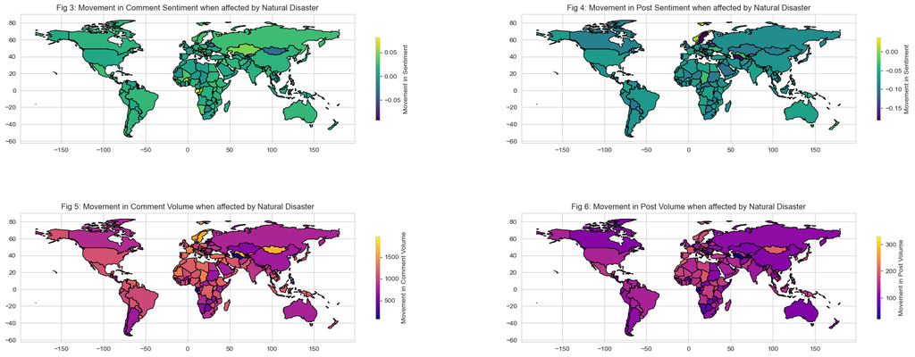

```python
# Import geopandas outline plot, create pyplot subplots
world = gpd.read_file(gpd.datasets.get_path('naturalearth_lowres'))
fig, axs = plt.subplots(2,2, figsize = (25,10))

world_plot_data.plot(ax=axs[0][0], column = "average sentiment_c", edgecolor='black', cmap = "viridis", legend = True, legend_kwds={'label': "Movement in Sentiment",'orientation': "vertical",'shrink': 0.5})
world_plot_data.plot(ax=axs[0][1], column = "average sentiment_p", edgecolor='black', cmap = "viridis", legend = True, legend_kwds={'label': "Movement in Sentiment",'orientation': "vertical",'shrink': 0.5})
world_plot_data.plot(ax=axs[1][0], column = "comment volume", edgecolor='black',cmap = "plasma",legend = True, legend_kwds={'label': "Movement in Comment Volume",'orientation': "vertical",'shrink': 0.5})
world_plot_data.plot(ax=axs[1][1], column = "post volume", edgecolor='black',cmap = "plasma",legend = True, legend_kwds={'label': "Movement in Post Volume",'orientation': "vertical",'shrink': 0.5})

axs[0][0].title.set_text("Fig 3: Movement in Comment Sentiment when affected by Natural Disaster")
axs[0][1].title.set_text("Fig 4: Movement in Post Sentiment when affected by Natural Disaster")
axs[1][0].title.set_text("Fig 5: Movement in Comment Volume when affected by Natural Disaster")
axs[1][1].title.set_text("Fig 6: Movement in Post Volume when affected by Natural Disaster")
```

However, the primary issue with this analysis is that the data was aggregated by date - multiple nations can be affected independently by disasters on the same day, but the total aggregate of the movements that they generate are distributed evenly which is not represented in the current format - addressing this discrepancy follows in the next section.

These geographic plots are created using [geopandas](https://geopandas.org/en/stable/), which is a library for managing and plotting geospatial data. The library is able to recognize the ISO codes of each nation, and convert the plot to a map with the specified value assigned to a standard colormap.

### Sentiment/Volume and Location Data Analysis

Now that the data is formatted in a more accessible way, it can be investigated for trends. What nations generate the most Reddit discourse or sentiment changes on days where they are affected by a natural disaster? Which natural disasters generate the most activity, and what do they have in common? How have the trends in natural disasters changed over time?

These questions can be answered using the `world_data`, `disaster_effects`, and `country_eda` tables, and analysis tools built into the sklearn library.

#### Maximum Movement by Disaster

**Post Volume:** The five most impactful natural disasters with respect to instant post volume are an earthquare in Pakistan in 2019, tropical storm 'Tapah' in Japan in 2019 and simultaneously in Korea, a water transport accident in the Congo in 2019, and tropical cyclone 'Lorena' in Mexico in 2019.

While there are a few interesting trends namely water-based disasters such as floods and storms seeming to dominate the results, the first immediate issue with these results is that multiple disasters happen on a given day - there is no way to determine if the effects on the Reddit data are because of attributes of any one storm. While parsing them apart is not possible, the dates with the highest activity can be found, and then all disasters happening on those dates called forwards from the `disaster_effects` table.

```python
# Find the 5 most impactful disasters by post volume
disaster_effects.sort_values(["post volume"], ascending = False).head(5)
```

|  | Dis No | Year | Seq | Disaster Group | Disaster Subgroup | Disaster Type | Disaster Subtype | Event Name | Country | ISO | ... | Total Deaths | CPI | Start Date | End Date | average sentiment_c | average score_c | comment volume | average sentiment_p | average score_p | post volume |
| --- | --- | --- | --- | --- | --- | --- | --- | --- | --- | --- | --- | --- | --- | --- | --- | --- | --- | --- | --- | --- | --- |
| 5694 | 2019-0460-PAK | 2019 | 460 | Natural | Geophysical | Earthquake | Ground movement | NaN | Pakistan | PAK | ... | 39.0 | 94.349092 | 2019-09-24 | 2019-09-24 | -0.073143 | 9.639153 | 12285.0 | -0.424079 | 37.823919 | 4072 |
| 5692 | 2019-0443-JPN | 2019 | 443 | Natural | Meteorological | Storm | Tropical cyclone | Tropical storm 'Tapah' | Japan | JPN | ... | NaN | 94.349092 | 2019-09-24 | 2019-09-24 | -0.073143 | 9.639153 | 12285.0 | -0.424079 | 37.823919 | 4072 |
| 5693 | 2019-0443-KOR | 2019 | 443 | Natural | Meteorological | Storm | Tropical cyclone | Tropical storm 'Tapah' | Korea (the Republic of) | KOR | ... | 2.0 | 94.349092 | 2019-09-24 | 2019-09-24 | -0.073143 | 9.639153 | 12285.0 | -0.424079 | 37.823919 | 4072 |
| 5655 | 2019-0439-COD | 2019 | 439 | Technological | Technological | Transport accident | Water | NaN | Congo (the Democratic Republic of the) | COD | ... | 36.0 | 94.349092 | 2019-09-20 | 2019-09-20 | -0.019109 | 9.232868 | 6523.0 | -0.179323 | 160.802441 | 2212 |
| 5653 | 2019-0418-MEX | 2019 | 418 | Natural | Meteorological | Storm | Tropical cyclone | Tropical cyclone 'Lorena' | Mexico | MEX | ... | 1.0 | 94.349092 | 2019-09-20 | 2019-09-20 | -0.019109 | 9.232868 | 6523.0 | -0.179323 | 160.802441 | 2212 |

5 rows × 26 columns

```python
# Find the 5 most impactful disasters by comment volume
disaster_effects.sort_values(["comment volume"], ascending = False).head(5)
```

|  | Dis No | Year | Seq | Disaster Group | Disaster Subgroup | Disaster Type | Disaster Subtype | Event Name | Country | ISO | ... | Total Deaths | CPI | Start Date | End Date | average sentiment_c | average score_c | comment volume | average sentiment_p | average score_p | post volume |
| --- | --- | --- | --- | --- | --- | --- | --- | --- | --- | --- | --- | --- | --- | --- | --- | --- | --- | --- | --- | --- | --- |
| 5694 | 2019-0460-PAK | 2019 | 460 | Natural | Geophysical | Earthquake | Ground movement | NaN | Pakistan | PAK | ... | 39.0 | 94.349092 | 2019-09-24 | 2019-09-24 | -0.073143 | 9.639153 | 12285.0 | -0.424079 | 37.823919 | 4072 |
| 5693 | 2019-0443-KOR | 2019 | 443 | Natural | Meteorological | Storm | Tropical cyclone | Tropical storm 'Tapah' | Korea (the Republic of) | KOR | ... | 2.0 | 94.349092 | 2019-09-24 | 2019-09-24 | -0.073143 | 9.639153 | 12285.0 | -0.424079 | 37.823919 | 4072 |
| 5692 | 2019-0443-JPN | 2019 | 443 | Natural | Meteorological | Storm | Tropical cyclone | Tropical storm 'Tapah' | Japan | JPN | ... | NaN | 94.349092 | 2019-09-24 | 2019-09-24 | -0.073143 | 9.639153 | 12285.0 | -0.424079 | 37.823919 | 4072 |
| 6197 | 2019-0453-TCD | 2019 | 453 | Natural | Hydrological | Landslide | Landslide | NaN | Chad | TCD | ... | 52.0 | 94.349092 | 2019-09-27 | 2019-09-27 | -0.063434 | 6.998311 | 7696.0 | -0.020295 | 84.482043 | 1253 |
| 5673 | 2019-0451-IDN | 2019 | 451 | Natural | Geophysical | Earthquake | Ground movement | NaN | Indonesia | IDN | ... | 31.0 | 94.349092 | 2019-09-26 | 2019-09-26 | -0.053284 | 9.750098 | 7675.0 | -0.154966 | 42.957672 | 1323 |

5 rows × 26 columns

```python
# Find the 5 most impactful disasters by post sentiment
disaster_effects.sort_values(["average sentiment_p"], ascending = False).head(5)
```

|  | Dis No | Year | Seq | Disaster Group | Disaster Subgroup | Disaster Type | Disaster Subtype | Event Name | Country | ISO | ... | Total Deaths | CPI | Start Date | End Date | average sentiment_c | average score_c | comment volume | average sentiment_p | average score_p | post volume |
| --- | --- | --- | --- | --- | --- | --- | --- | --- | --- | --- | --- | --- | --- | --- | --- | --- | --- | --- | --- | --- | --- |
| 5670 | 2019-0445-HTI | 2019 | 445 | Natural | Hydrological | Flood | Flash flood | NaN | Haiti | HTI | ... | 6.0 | 94.349092 | 2019-09-18 | 2019-09-21 | -0.009587 | 11.143214 | 4001.0 | 0.45868 | 107.065905 | 1487 |
| 1802 | 2011-0539-ZWE | 2011 | 539 | Technological | Technological | Transport accident | Water | NaN | Zimbabwe | ZWE | ... | 11.0 | 83.012674 | 2011-12-25 | 2011-12-25 | 0.186837 | 1.953488 | 43.0 | 0.38180 | 2.000000 | 1 |
| 1801 | 2011-0565-PHL | 2011 | 565 | Technological | Technological | Transport accident | Road | Cargo | Philippines (the) | PHL | ... | 22.0 | 83.012674 | 2011-12-25 | 2011-12-25 | 0.186837 | 1.953488 | 43.0 | 0.38180 | 2.000000 | 1 |
| 1800 | 2011-0540-PHL | 2011 | 540 | Natural | Hydrological | Flood | Riverine flood | NaN | Philippines (the) | PHL | ... | 12.0 | 83.012674 | 2011-12-25 | 2011-12-28 | 0.186837 | 1.953488 | 43.0 | 0.38180 | 2.000000 | 1 |
| 958 | 2011-0125-YEM | 2011 | 125 | Technological | Technological | Industrial accident | Explosion | Amunitions factory | Yemen | YEM | ... | 70.0 | 83.012674 | 2011-03-28 | 2011-03-28 | -0.170313 | 2.393443 | 61.0 | 0.37322 | 5.000000 | 5 |

5 rows × 26 columns

```python
# Find the 5 most impactful disasters by comment sentiment
disaster_effects.sort_values(["average sentiment_c"], ascending = False).head(5)
```

|  | Dis No | Year | Seq | Disaster Group | Disaster Subgroup | Disaster Type | Disaster Subtype | Event Name | Country | ISO | ... | Total Deaths | CPI | Start Date | End Date | average sentiment_c | average score_c | comment volume | average sentiment_p | average score_p | post volume |
| --- | --- | --- | --- | --- | --- | --- | --- | --- | --- | --- | --- | --- | --- | --- | --- | --- | --- | --- | --- | --- | --- |
| 679 | 2011-0136-IND | 2011 | 136 | Technological | Technological | Transport accident | Air | Helicopter | India | IND | ... | 18.0 | 83.012674 | 2011-04-19 | 2011-04-19 | 0.372892 | 1.830189 | 53.0 | -0.187057 | 4.928571 | 14 |
| 680 | 2011-0137-COD | 2011 | 137 | Technological | Technological | Transport accident | Road | NaN | Congo (the Democratic Republic of the) | COD | ... | 32.0 | 83.012674 | 2011-04-19 | 2011-04-19 | 0.372892 | 1.830189 | 53.0 | -0.187057 | 4.928571 | 14 |
| 347 | 2010-0299-DEU | 2010 | 299 | Technological | Technological | Miscellaneous accident | Other | Stampede | Germany | DEU | ... | 21.0 | 80.472285 | 2010-07-24 | 2010-07-24 | 0.351994 | 1.352941 | 17.0 | -0.061620 | 2.600000 | 5 |
| 346 | 2010-0355-CHN | 2010 | 355 | Technological | Technological | Miscellaneous accident | Collapse | Bridge | China | CHN | ... | 41.0 | 80.472285 | 2010-07-24 | 2010-07-24 | 0.351994 | 1.352941 | 17.0 | -0.061620 | 2.600000 | 5 |
| 30 | 2010-0102-AUS | 2010 | 102 | Natural | Meteorological | Storm | Convective storm | NaN | Australia | AUS | ... | NaN | 80.472285 | 2010-03-06 | 2010-03-10 | 0.348497 | 1.413793 | 29.0 | 0.083800 | 2.062500 | 16 |

5 rows × 26 columns

#### Maximum Movement by Date

**Post Volume:** The three events that occurred on the date with the highest post volume were tropical storm Tapah in Japan in 2019, the same storm in Korea, and an earthquake in Pakistan in 2019.

**Comment Volume:** The same three events occurred on the date with the highest comment volume.

```python
# Get all disasters on days with maximum comment volume
disaster_effects[disaster_effects["Start Date"] == reddit_comment_days.loc[reddit_comment_days["comment volume"].idxmax()]["date"]]
```

|  | Dis No | Year | Seq | Disaster Group | Disaster Subgroup | Disaster Type | Disaster Subtype | Event Name | Country | ISO | ... | Total Deaths | CPI | Start Date | End Date | average sentiment_c | average score_c | comment volume | average sentiment_p | average score_p | post volume |
| --- | --- | --- | --- | --- | --- | --- | --- | --- | --- | --- | --- | --- | --- | --- | --- | --- | --- | --- | --- | --- | --- |
| 5692 | 2019-0443-JPN | 2019 | 443 | Natural | Meteorological | Storm | Tropical cyclone | Tropical storm 'Tapah' | Japan | JPN | ... | NaN | 94.349092 | 2019-09-24 | 2019-09-24 | -0.073143 | 9.639153 | 12285.0 | -0.424079 | 37.823919 | 4072 |
| 5693 | 2019-0443-KOR | 2019 | 443 | Natural | Meteorological | Storm | Tropical cyclone | Tropical storm 'Tapah' | Korea (the Republic of) | KOR | ... | 2.0 | 94.349092 | 2019-09-24 | 2019-09-24 | -0.073143 | 9.639153 | 12285.0 | -0.424079 | 37.823919 | 4072 |
| 5694 | 2019-0460-PAK | 2019 | 460 | Natural | Geophysical | Earthquake | Ground movement | NaN | Pakistan | PAK | ... | 39.0 | 94.349092 | 2019-09-24 | 2019-09-24 | -0.073143 | 9.639153 | 12285.0 | -0.424079 | 37.823919 | 4072 |

3 rows × 26 columns

```python
# Get all disasters on days with maximum post volume
disaster_effects[disaster_effects["Start Date"] == reddit_post_days.loc[reddit_post_days["post volume"].idxmax()]["date"]]
```

|  | Dis No | Year | Seq | Disaster Group | Disaster Subgroup | Disaster Type | Disaster Subtype | Event Name | Country | ISO | ... | Total Deaths | CPI | Start Date | End Date | average sentiment_c | average score_c | comment volume | average sentiment_p | average score_p | post volume |
| --- | --- | --- | --- | --- | --- | --- | --- | --- | --- | --- | --- | --- | --- | --- | --- | --- | --- | --- | --- | --- | --- |
| 5692 | 2019-0443-JPN | 2019 | 443 | Natural | Meteorological | Storm | Tropical cyclone | Tropical storm 'Tapah' | Japan | JPN | ... | NaN | 94.349092 | 2019-09-24 | 2019-09-24 | -0.073143 | 9.639153 | 12285.0 | -0.424079 | 37.823919 | 4072 |
| 5693 | 2019-0443-KOR | 2019 | 443 | Natural | Meteorological | Storm | Tropical cyclone | Tropical storm 'Tapah' | Korea (the Republic of) | KOR | ... | 2.0 | 94.349092 | 2019-09-24 | 2019-09-24 | -0.073143 | 9.639153 | 12285.0 | -0.424079 | 37.823919 | 4072 |
| 5694 | 2019-0460-PAK | 2019 | 460 | Natural | Geophysical | Earthquake | Ground movement | NaN | Pakistan | PAK | ... | 39.0 | 94.349092 | 2019-09-24 | 2019-09-24 | -0.073143 | 9.639153 | 12285.0 | -0.424079 | 37.823919 | 4072 |

3 rows × 26 columns

```python
# Get all disasters on days with maximum comment sentiment
disaster_effects[disaster_effects["Start Date"] == reddit_comment_days.loc[reddit_comment_days["average sentiment"].idxmax()]["date"]]
```

|  | Dis No | Year | Seq | Disaster Group | Disaster Subgroup | Disaster Type | Disaster Subtype | Event Name | Country | ISO | ... | Total Deaths | CPI | Start Date | End Date | average sentiment_c | average score_c | comment volume | average sentiment_p | average score_p | post volume |
| --- | --- | --- | --- | --- | --- | --- | --- | --- | --- | --- | --- | --- | --- | --- | --- | --- | --- | --- | --- | --- | --- |

0 rows × 26 columns

```python
# Get all disasters on days with minimum comment sentiment
disaster_effects[disaster_effects["Start Date"] == reddit_comment_days.loc[reddit_comment_days["average sentiment"].idxmin()]["date"]]
```

|  | Dis No | Year | Seq | Disaster Group | Disaster Subgroup | Disaster Type | Disaster Subtype | Event Name | Country | ISO | ... | Total Deaths | CPI | Start Date | End Date | average sentiment_c | average score_c | comment volume | average sentiment_p | average score_p | post volume |
| --- | --- | --- | --- | --- | --- | --- | --- | --- | --- | --- | --- | --- | --- | --- | --- | --- | --- | --- | --- | --- | --- |
| 3784 | 2017-0214-CHN | 2017 | 214 | Natural | Meteorological | Storm | Convective storm | NaN | China | CHN | ... | 9.0 | 90.460179 | 2017-05-20 | 2017-05-24 | -0.435349 | 3.640784 | 1275.0 | -0.103801 | 17.212121 | 165 |
| 3785 | 2017-0216-GUY | 2017 | 216 | Natural | Hydrological | Flood | Riverine flood | NaN | Guyana | GUY | ... | NaN | 90.460179 | 2017-05-20 | 2017-05-25 | -0.435349 | 3.640784 | 1275.0 | -0.103801 | 17.212121 | 165 |

2 rows × 26 columns

```python
# Get all disasters on days with maximum post sentiment
disaster_effects[disaster_effects["Start Date"] == reddit_post_days.loc[reddit_post_days["average sentiment"].idxmax()]["date"]]
```

|  | Dis No | Year | Seq | Disaster Group | Disaster Subgroup | Disaster Type | Disaster Subtype | Event Name | Country | ISO | ... | Total Deaths | CPI | Start Date | End Date | average sentiment_c | average score_c | comment volume | average sentiment_p | average score_p | post volume |
| --- | --- | --- | --- | --- | --- | --- | --- | --- | --- | --- | --- | --- | --- | --- | --- | --- | --- | --- | --- | --- | --- |
| 5670 | 2019-0445-HTI | 2019 | 445 | Natural | Hydrological | Flood | Flash flood | NaN | Haiti | HTI | ... | 6.0 | 94.349092 | 2019-09-18 | 2019-09-21 | -0.009587 | 11.143214 | 4001.0 | 0.45868 | 107.065905 | 1487 |

1 rows × 26 columns

```python
# Get all disasters on days with minimum post sentiment
disaster_effects[disaster_effects["Start Date"] == reddit_post_days.loc[reddit_post_days["average sentiment"].idxmin()]["date"]]
```

|  | Dis No | Year | Seq | Disaster Group | Disaster Subgroup | Disaster Type | Disaster Subtype | Event Name | Country | ISO | ... | Total Deaths | CPI | Start Date | End Date | average sentiment_c | average score_c | comment volume | average sentiment_p | average score_p | post volume |
| --- | --- | --- | --- | --- | --- | --- | --- | --- | --- | --- | --- | --- | --- | --- | --- | --- | --- | --- | --- | --- | --- |
| 1744 | 2014-0009-CAN | 2014 | 9 | Natural | Meteorological | Extreme temperature | Cold wave | NaN | Canada | CAN | ... | NaN | 87.366298 | 2014-01-01 | 2014-01-09 | -0.035215 | 2.451923 | 208.0 | -0.538241 | 19.62069 | 29 |
| 1745 | 2014-0035-BOL | 2014 | 35 | Natural | Hydrological | Landslide | Landslide | NaN | Bolivia (Plurinational State of) | BOL | ... | 74.0 | 87.366298 | 2014-01-01 | 2014-02-28 | -0.035215 | 2.451923 | 208.0 | -0.538241 | 19.62069 | 29 |
| 1746 | 2014-0534-PER | 2014 | 534 | Natural | Hydrological | Flood | Riverine flood | NaN | Peru | PER | ... | 21.0 | 87.366298 | 2014-01-01 | 2014-01-20 | -0.035215 | 2.451923 | 208.0 | -0.538241 | 19.62069 | 29 |
| 1747 | 2014-0567-PHL | 2014 | 567 | Technological | Technological | Miscellaneous accident | Explosion | Fireworks | Philippines (the) | PHL | ... | 2.0 | 87.366298 | 2014-01-01 | 2014-01-01 | -0.035215 | 2.451923 | 208.0 | -0.538241 | 19.62069 | 29 |
| 1748 | 2014-0052-USA | 2014 | 52 | Natural | Meteorological | Storm | Convective storm | NaN | United States of America (the) | USA | ... | 16.0 | 87.366298 | 2014-01-01 | 2014-01-05 | -0.035215 | 2.451923 | 208.0 | -0.538241 | 19.62069 | 29 |

5 rows × 26 columns

### Inclusion of OWID Datasets

From here, the OWID CO2 and Internet Penetration data is added to the overall disaster effects table. The merge is tricky, since for each disaster the imported data value per year and GDP must be for the right nation and year simultaneously. Once done, this allows for disasters to be queried by the amount of co2 that each affected country emitted in that year, the internet access that the nation has, and its GDP for that same point in time.

```python
# Take select variables
co2_data_trim = co2_data[["year","iso_code", "population", "gdp", "co2"]]
# Pivot to multi-index
co2_pivot = co2_data_trim.pivot_table(index = ["iso_code","year"], values = ["co2", "gdp"])
internet_pivot = internet_data.pivot_table(index = ["Year", "Code"], values = ["Number of Internet users"])
# Merge disaster effects with co2 data by year and date
disaster_effects_master = disaster_effects.merge(co2_pivot, left_on = ["ISO", "Year"],right_on = ["iso_code", "year"])
disaster_effects_master = disaster_effects_master.merge(internet_pivot, left_on = ["ISO", "Year"], right_on = ["Code", "Year"])
disaster_effects_master.head(3)
```

|  | Dis No | Year | Seq | Disaster Group | Disaster Subgroup | Disaster Type | Disaster Subtype | Event Name | Country | ISO | ... | End Date | average sentiment_c | average score_c | comment volume | average sentiment_p | average score_p | post volume | co2 | gdp | Number of Internet users |
| --- | --- | --- | --- | --- | --- | --- | --- | --- | --- | --- | --- | --- | --- | --- | --- | --- | --- | --- | --- | --- | --- |
| 0 | 2010-0005-IND | 2010 | 5 | Technological | Technological | Transport accident | Rail | NaN | India | IND | ... | 2010-01-02 | -0.004041 | 3.081081 | 37.0 | 0.025733 | 1.333333 | 6 | 1677.888 | 5.314517e+12 | 93046022 |
| 1 | 2010-0177-IND | 2010 | 177 | Natural | Meteorological | Storm | Convective storm | NaN | India | IND | ... | 2010-05-08 | -0.208146 | 6.961538 | 26.0 | 0.179991 | 67.181818 | 11 | 1677.888 | 5.314517e+12 | 93046022 |
| 2 | 2010-0487-IND | 2010 | 487 | Technological | Technological | Transport accident | Rail | NaN | India | IND | ... | 2010-09-20 | -0.060712 | 2.184615 | 65.0 | -0.089635 | 16.521739 | 23 | 1677.888 | 5.314517e+12 | 93046022 |

3 rows × 29 columns

### Correlation Matrix of Numeric Features

This plot is the correlation matrix of numeric values in the table relating natural disasters and social media data. Certain values such as End Date, Local Time, and Local Location were dropped, and the Start Date was converted to a floating point decimal of seconds since epoch to be used as a numerical data value. However, this includes all missing data, of which the more strongly correlated data include more of, so it is possible that increased sparsity could account for the stronger correlation.

While the trend is not as strong as the initially predicted, it could still be possible to parse the remaining relationships with an advanced model.

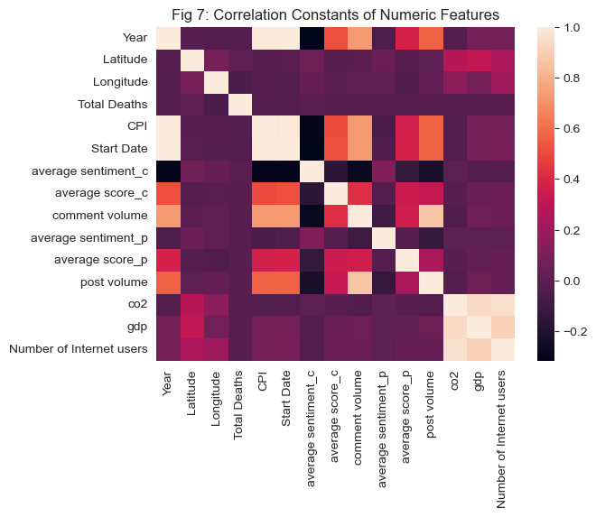

```python
disaster_effects_num = disaster_effects_master.copy()
# Convert datetime into seconds since epoch, drop labelling attributes
disaster_effects_num["Start Date"] = disaster_effects_num[["Start Date"]].applymap(lambda x: float(x.strftime('%s')))
disaster_effects_num.drop(["End Date", "Local Time", "Seq", "Dis No","Location"], axis = 1, inplace = True)
# Generate correlation matrix and heatmap
ded_corr = disaster_effects_num.corr(numeric_only = True)
ax = plt.axes()
sns.heatmap(ded_corr, ax = ax)
ax.set_title("Fig 7: Correlation Constants of Numeric Features")
```

## Model Creation - Can Sentiment Activity Be Predicted?

From there, a regression model will be introduced to predict the outcome of future disaster events and the effects that they will have on Reddit discussion volume and sentiment. Given the inherently categorical nature of grouping these events by nationality, the most ideal model system is a Decision Forest, since it is highly flexible and can be used on a dataset of mixed categorical vectors and continuous data. Furthermore, since there are only a few parameters being used in this model as an exploration of a relationship, not necessarily as a guarantee of future predictive power, the total depth of the Decision Forest has the potential to be very low, and result in a more simple model.

For the Decision Tree models. I will use [XGBoost Boosted Decision Forests](https://xgboost.readthedocs.io/en/stable/python/python_api.html#module-xgboost.sklearnhttps://xgboost.readthedocs.io/en/stable/python/python_api.html#module-xgboost.sklearn) through their SKLearn API. These are fantastic and incredibly powerful models, that are ensembles of decision trees, of which each individual decision tree is trained off of the residual error of the prior tree. They also have a very neat feature where you can access and query the underlying model directly using the built-in ['get_booster()'](https://xgboost.readthedocs.io/en/stable/python/python_api.html#xgboost.XGBClassifier.get_boosterhttps://xgboost.readthedocs.io/en/stable/python/python_api.html#xgboost.XGBClassifier.get_booster) function, meaning that the individual importance features and statistics for each model can be read after fitting.

### Model Selection and Hyperparameter Grid Search

Since there are two different content types, and two different metrics each, there will be four separate regression models created, each with one of the content metrics as the target parameter. The start time will be converted into a seconds since epoch measurement, so that it can be treated as a numerical variable, and all of the categorical variables will be one-hot encoded into binary vectors.

From here, each of the regression models are trained across a variety of hyperparameters to find the configuration that yields the most accurate predictions with respect to testing error. The hyperparameters examined are various boosting algorithms, the total number of boosting rounds (which is the same as the number of trees trained recursively on the previous trees' residual error) and various values for the regularization term alpha. These sweeps through various hyperparameter values are done manually, as opposed to with a built-in function so that the data from each version can be stored into a global array and visualized.

**Note that these models are fairly complex and operating on a large dataset- depending on the underlying kernel and hardware, these cells could take a large (>10 hours) amount of time to compute.**

```python
# Get copy of descriptive variables
disaster_effects_ml = disaster_effects_master.copy()[["Disaster Group", "Disaster Type", "ISO", "Continent", "Total Deaths", "CPI", "Start Date", "Latitude", "Longitude", "comment volume", "post volume", "average sentiment_c", "average sentiment_p", "gdp", "co2", "Number of Internet users"]]
# Remove more empty rows or irreferential rows
disaster_effects_ml.dropna(subset = ["Disaster Group", "Disaster Type", "Continent"])
# Convert start date into epoch seconds
disaster_effects_ml["Start Date"] = disaster_effects_ml[["Start Date"]].applymap(lambda x: float(x.strftime('%s')))
# One-hot encode categorical variables
disaster_effects_ml_dummies = pd.get_dummies(disaster_effects_ml)

# Split into samples and features for each different model

vol_c = disaster_effects_ml_dummies["comment volume"]
vol_p = disaster_effects_ml_dummies["post volume"]
sent_c = disaster_effects_ml_dummies["average sentiment_c"]
sent_p = disaster_effects_ml_dummies["average sentiment_p"]
disaster_effects_ml_data = pd.get_dummies(disaster_effects_ml[["Disaster Group", "Disaster Type", "ISO", "Continent", "Total Deaths", "CPI", "Start Date", "gdp", "co2", "Number of Internet users"]].copy())
vol_c_X_test, vol_c_X_train, vol_c_y_test, vol_c_y_train = train_test_split(disaster_effects_ml_data, vol_c, random_state = 0, test_size = 0.20)
vol_p_X_test, vol_p_X_train, vol_p_y_test, vol_p_y_train = train_test_split(disaster_effects_ml_data, vol_p, random_state = 0, test_size = 0.20)
sent_c_X_test, sent_c_X_train, sent_c_y_test, sent_c_y_train = train_test_split(disaster_effects_ml_data, sent_c, random_state = 0, test_size = 0.20)
sent_p_X_test, sent_p_X_train, sent_p_y_test, sent_p_y_train = train_test_split(disaster_effects_ml_data, sent_p, random_state = 0, test_size = 0.20)
```

```python
# XGB Model Hyperparameter Grid Search
cv_dt_errors = []
pv_dt_errors = []
cs_dt_errors = []
ps_dt_errors = []

num_boosts = [1,2,3,5,10,20,30,50,100,125,150,175,200]
boosters = ["gbtree","gblinear","dart"]
# l1 norm penalization terms
alphas = [0,0.1,0.3,0.5,0.7,0.9]

# Comment volume xgb hyperparameters
for b in num_boosts:
    for boost in boosters:
        for alpha in alphas:
            cv_xgb_regressor = xgb.XGBRegressor(n_estimators = b,
                                                booster = boost, n_jobs = -1,
                                                alpha = alpha, random_state = 0, missing = np.nan,
                                                eval_metric = mean_squared_error)
            cv_xgb_regressor.fit(vol_c_X_train, vol_c_y_train)
            cv_xgb_test_pred = cv_xgb_regressor.predict(vol_c_X_test)
            cv_xgb_train_pred = cv_xgb_regressor.predict(vol_c_X_train)
            train_mse = mean_squared_error(vol_c_y_train, cv_xgb_train_pred)
            test_mse = mean_squared_error(vol_c_y_test, cv_xgb_test_pred)
            cv_dt_errors.append([b, boost, alpha, train_mse, test_mse])

cv_dt_opt = [e for e in cv_dt_errors if e[-1]== min([f[-1] for f in cv_dt_errors])]
print("Best Comment Volume XGB Parameters:",cv_dt_opt)

# Post volume xgb hyperparameters
for b in num_boosts:
    for boost in boosters:
        for alpha in alphas:
            pv_xgb_regressor = xgb.XGBRegressor(n_estimators = b,
                                                booster = boost, n_jobs = -1,
                                                alpha = alpha, random_state = 0, missing = np.nan,
                                                eval_metric = mean_squared_error)
            pv_xgb_regressor.fit(vol_p_X_train, vol_p_y_train)
            pv_xgb_test_pred = pv_xgb_regressor.predict(vol_p_X_test)
            pv_xgb_train_pred = pv_xgb_regressor.predict(vol_p_X_train)
            train_mse = mean_squared_error(vol_p_y_train, pv_xgb_train_pred)
            test_mse = mean_squared_error(vol_p_y_test, pv_xgb_test_pred)
            pv_dt_errors.append([b, boost, alpha, train_mse, test_mse])

pv_dt_opt = [e for e in pv_dt_errors if e[-1]== min([f[-1] for f in pv_dt_errors])]
print("Best Post Volume XGB Parameters:",pv_dt_opt)

# Comment sentiment xgb hyperparameters
for b in num_boosts:
    for boost in boosters:
        for alpha in alphas:
            cs_xgb_regressor = xgb.XGBRegressor(n_estimators = b,
                                                booster = boost, n_jobs = -1,
                                                alpha = alpha, random_state = 0, missing = np.nan,
                                                eval_metric = mean_squared_error)
            cs_xgb_regressor.fit(sent_c_X_train,sent_c_y_train)
            cs_xgb_test_pred = cs_xgb_regressor.predict(sent_c_X_test)
            cs_xgb_train_pred = cs_xgb_regressor.predict(sent_c_X_train)
            train_mse = mean_squared_error(sent_c_y_train, cs_xgb_train_pred)
            test_mse = mean_squared_error(sent_c_y_test, cs_xgb_test_pred)
            cs_dt_errors.append([b, boost, alpha, train_mse, test_mse])

cs_dt_opt = [e for e in cs_dt_errors if e[-1]== min([f[-1] for f in cs_dt_errors])]
print("Best Comment Sentiment XGB Parameters:",cs_dt_opt)

# Post sentiment xgb hyperparameters
for b in num_boosts:
    for boost in boosters:
        for alpha in alphas:
            ps_xgb_regressor = xgb.XGBRegressor(n_estimators = b,
                                                booster = boost, n_jobs = -1,
                                                alpha = alpha, random_state = 0, missing = np.nan,
                                                eval_metric = mean_squared_error)
            ps_xgb_regressor.fit(sent_p_X_train,sent_p_y_train)
            ps_xgb_test_pred = ps_xgb_regressor.predict(sent_p_X_test)
            ps_xgb_train_pred = ps_xgb_regressor.predict(sent_p_X_train)
            train_mse = mean_squared_error(sent_p_y_train, ps_xgb_train_pred)
            test_mse = mean_squared_error(sent_p_y_test, ps_xgb_test_pred)
            ps_dt_errors.append([b, boost, alpha, train_mse, test_mse])

ps_dt_opt = [e for e in ps_dt_errors if e[-1]== min([f[-1] for f in ps_dt_errors])][0]
print("Best Post Sentiment XGB Parameters:",ps_dt_opt)
```

```
Best Comment Volume XGB Parameters: [[10, 'gbtree', 0.5, 54830.0911372959, 170316.29375201755]]
Best Post Volume XGB Parameters: [[5, 'gbtree', 0.9, 9562.870823862731, 17835.084847694212]]
Best Comment Sentiment XGB Parameters: [[20, 'gbtree', 0.9, 0.0033176040992675907, 0.004811298276337284]]
Best Post Sentiment XGB Parameters: [3, 'gblinear', 0.3, 0.010611916231847368, 0.010732385385554951]
```